# Results - Classes

Research Questions?

RQ1. Which group of metrics are most related to inserting bugs?

RQ2. Inside these groups, which metrics are most related to inserting bugs?

- **General:**

```r
library(dplyr)
resultsGen <- read.csv(file = "/home/r4ph/results/classes/analysis/resume/resultsGeneral.csv", stringsAsFactors = FALSE)
#resultsGen <- rbind(resultsGen,colSums(Filter(is.numeric, resultsGen)))
resultsGen <- resultsGen[order(-resultsGen$numberofPosGranger),]
total <- c(10, "Total", sum(resultsGen$numberofClasses), sum(resultsGen$numberofGranger), sum(resultsGen$numberofPosGranger), median(resultsGen$PercGranger))
resultsGen <- rbind(resultsGen, total)
resultsGen$X <- resultsGen$PercGranger <- NULL
resultsGen
```

|  | projects.i. | numberofClasses | numberofGranger | numberofPosGranger |
| --- | --- | --- | --- | --- |
| 7 | Presto | 7973 | 1801 | 210 |
| 5 | Netty | 5764 | 1473 | 154 |
| 8 | RxJava | 4837 | 1479 | 117 |
| 6 | Okhttp | 1217 | 659 | 113 |
| 2 | Fresco | 1082 | 188 | 28 |
| 1 | Elasticsearch-hadoop | 870 | 213 | 18 |
| 3 | Hystrix | 591 | 125 | 15 |
| 4 | Material Drawer | 158 | 40 | 13 |
| 9 | Total | 22492 | 5978 | 668 |

```r
#summary(resultsGen)
```

- **Add/Del Groups:**

```r
resultsGroups <- read.csv(file = "/home/r4ph/results/classes/analysis/resume/resultsAddDel.csv", stringsAsFactors = FALSE)
#resultsGen <- rbind(resultsGen,colSums(Filter(is.numeric, resultsGen)))
resultsGroups <- resultsGroups[order(-resultsGroups$numberofPosGranger),]
total <- c(10, "Total", "Total", sum(resultsGroups$numberofClasses), sum(resultsGroups$numberofGranger), sum(resultsGroups$numberofPosGranger), median(resultsGroups$PercGranger))
resultsGroups <- rbind(resultsGroups, total)
resultsGroups$X <- resultsGroups$PercGranger <- NULL
resultsGroups
```

|  | projects.i. | changeTypes.j. | numberofClasses | numberofGranger | numberofPosGranger |
| --- | --- | --- | --- | --- | --- |
| 13 | Presto | changeMetricsAddition | 7967 | 1563 | 175 |
| 14 | Presto | changeMetricsDeletion | 6244 | 1152 | 144 |
| 10 | Netty | changeMetricsDeletion | 4859 | 793 | 98 |
| 9 | Netty | changeMetricsAddition | 5761 | 1096 | 97 |
| 15 | RxJava | changeMetricsAddition | 4816 | 908 | 84 |
| 16 | RxJava | changeMetricsDeletion | 4304 | 649 | 74 |
| 11 | Okhttp | changeMetricsAddition | 1216 | 442 | 64 |
| 12 | Okhttp | changeMetricsDeletion | 1135 | 357 | 59 |
| 3 | Fresco | changeMetricsAddition | 1082 | 155 | 24 |
| 1 | Elasticsearch-hadoop | changeMetricsAddition | 870 | 163 | 11 |

[output cut: 7 more lines]

```r
#summary(resultsGroups)
```

- **Summarizing the metrics by groups of type changes:**

```r
resultsGroupsSum <- read.csv(file = "/home/r4ph/results/classes/analysis/resume/resultsAddDel.csv", stringsAsFactors = FALSE)
dat.grp <- group_by(resultsGroupsSum, changeTypes.j. )
dataSum <- summarise(dat.grp, NClasses=sum(numberofClasses), NGranger = sum(numberofGranger), NPosGranger = sum(numberofPosGranger))
dataSum$Perc <- NULL
dataSum
```

| changeTypes.j. | NClasses | NGranger | NPosGranger |
| --- | --- | --- | --- |
| changeMetricsAddition | 22461 | 4469 | 472 |
| changeMetricsDeletion | 18603 | 3212 | 404 |

- **Groups of metric types:**

```r
resultsGrp <- read.csv(file = "/home/r4ph/results/classes/analysis/resume/resultsGroups.csv", stringsAsFactors = FALSE)
resultsGrp <- resultsGrp[order(-resultsGrp$numberofPosGranger),]
total <- c(10, "Total", "Total", "Total", sum(resultsGrp$numberofClasses), sum(resultsGrp$numberofGranger), sum(resultsGrp$numberofPosGranger), median(resultsGrp$PercGranger))
resultsGrp <- rbind(resultsGrp, total)
resultsGrp$X <- resultsGrp$PercGranger <- NULL
resultsGrp
```

|  | projects.i. | changeTypes.j. | groups.x. | numberofClasses | numberofGranger | numberofPosGranger |
| --- | --- | --- | --- | --- | --- | --- |
| 249 | Presto | changeMetricsAddition | NOIP | 7605 | 1275 | 152 |
| 269 | Presto | changeMetricsDeletion | NOIP | 5634 | 792 | 119 |
| 254 | Presto | changeMetricsAddition | NOMD | 7539 | 755 | 70 |
| 169 | Netty | changeMetricsAddition | NOIP | 5109 | 679 | 67 |
| 274 | Presto | changeMetricsDeletion | NOMD | 5122 | 433 | 55 |
| 289 | RxJava | changeMetricsAddition | NOIP | 4575 | 579 | 51 |
| 174 | Netty | changeMetricsAddition | NOMD | 4963 | 490 | 42 |
| 214 | Okhttp | changeMetricsAddition | NOMD | 1160 | 291 | 40 |
| 189 | Netty | changeMetricsDeletion | NOIP | 4166 | 435 | 39 |
| 234 | Okhttp | changeMetricsDeletion | NOMD | 1023 | 215 | 39 |

[output cut: 311 more lines]

```r
#summary(resultsGroups)
```

- **Summarizing the groups of metrics types:**

```r
resultsGroupsMetrics <- read.csv(file = "/home/r4ph/results/classes/analysis/resume/resultsGroups.csv", stringsAsFactors = FALSE)
dat.grp.met <- group_by(resultsGroupsMetrics, groups.x.)
dataSumMet <- summarise(dat.grp.met, NClasses=sum(numberofClasses), NGranger = sum(numberofGranger), NPosGranger = sum(numberofPosGranger))
dataSumMet$Perc <- NULL
dataSumMet <- dataSumMet[order(-dataSumMet$NPosGranger),]
dataSumMet
```

| groups.x. | NClasses | NGranger | NPosGranger |
| --- | --- | --- | --- |
| NOIP | 37434 | 4999 | 571 |
| NOMD | 35683 | 3313 | 379 |
| NOF | 23979 | 1212 | 129 |
| NOLI | 10977 | 398 | 48 |
| NOO | 7208 | 206 | 25 |
| NOMC | 5984 | 181 | 21 |
| NOAN | 4968 | 18 | 5 |
| NOAR | 1494 | 18 | 5 |
| NOJ | 1245 | 26 | 3 |
| NOE | 2332 | 28 | 2 |

[output cut: 10 more lines]

- **Individual Metrics:**

```r
resultsInd <- read.csv(file = "/home/r4ph/results/classes/analysis/resume/resultsMetrics.csv", stringsAsFactors = FALSE)
resultsInd <- filter(resultsInd, numberofPosGranger != 0)
resultsInd <- resultsInd[order(-resultsInd$numberofPosGranger),]
total <- c(10, "Total", "Total", "Total", sum(resultsInd$numberofClasses), sum(resultsInd$numberofGranger), sum(resultsInd$numberofPosGranger), median(resultsInd$PercGranger))
resultsInd <- rbind(resultsInd, total)
resultsInd$X <- resultsInd$PercGranger <- NULL
resultsInd
```

|  | projects.i. | changeTypes.j. | metrics.x. | numberofClasses | numberofGranger | numberofPosGranger |
| --- | --- | --- | --- | --- | --- | --- |
| 129 | Presto | changeMetricsAddition | SIMPLE_NAME | 5717 | 1493 | 160 |
| 128 | Presto | changeMetricsAddition | QUALIFIED_NAME | 5024 | 1380 | 148 |
| 144 | Presto | changeMetricsDeletion | SIMPLE_NAME | 4859 | 1025 | 115 |
| 143 | Presto | changeMetricsDeletion | QUALIFIED_NAME | 4929 | 904 | 114 |
| 86 | Netty | changeMetricsDeletion | SIMPLE_NAME | 4606 | 667 | 75 |
| 157 | RxJava | changeMetricsAddition | SIMPLE_NAME | 4094 | 729 | 68 |
| 70 | Netty | changeMetricsAddition | SIMPLE_NAME | 5582 | 853 | 63 |
| 102 | Okhttp | changeMetricsAddition | SIMPLE_NAME | 1212 | 374 | 56 |
| 85 | Netty | changeMetricsDeletion | QUALIFIED_NAME | 4451 | 486 | 54 |
| 69 | Netty | changeMetricsAddition | QUALIFIED_NAME | 5553 | 709 | 53 |

[output cut: 158 more lines]

- **Summarizing ind. metrics:**

```r
resultsIndMetrics <- read.csv(file = "/home/r4ph/results/classes/analysis/resume/resultsMetrics.csv", stringsAsFactors = FALSE)
dat.grp.ind <- group_by(resultsIndMetrics, metrics.x.)
dataSumInd <- summarise(dat.grp.ind, NClasses=sum(numberofClasses), NGranger = sum(numberofGranger), NPosGranger = sum(numberofPosGranger))
dataSumInd$Perc <- NULL
dataSumInd <- dataSumInd[order(-dataSumInd$NPosGranger),]
dataSumInd
```

| metrics.x. | NClasses | NGranger | NPosGranger |
| --- | --- | --- | --- |
| SIMPLE_NAME | 35158 | 6484 | 681 |
| QUALIFIED_NAME | 34027 | 5452 | 555 |
| VARIABLE_DECLARATION_FRAGMENT | 21086 | 1297 | 149 |
| SIMPLE_TYPE | 25158 | 1538 | 144 |
| MODIFIER | 31030 | 1563 | 137 |
| FIELD_DECLARATION | 20985 | 1229 | 132 |
| PARAMETERIZED_TYPE | 11612 | 364 | 40 |
| STRING_LITERAL | 4785 | 195 | 29 |
| CLASS_INSTANCE_CREATION | 6400 | 214 | 27 |
| METHOD_INVOCATION | 5238 | 184 | 20 |

[output cut: 54 more lines]

RQ3. Is a variability of changes metrics more conducive to introduce a bug than specific metrics?

**General Questions?**

G1.Which group of metrics are most related to inserting bugs? By addition and removal?

Tiveram mais casos positivos de granger em mudanças relacionadas a adição de métricas. ressaltando que quanto menor o nível de granularidade, maior o aumento da diferença entre a ocorrência de bugs. Porém isso está ligado ao numero absoluto da quantidade. Uma analise relativa demonstra que não há diferença relevante, visto que há somente os seguintes percentuais:

- Changes:

Add: 0.02272022%

Del: 0.022104%

- Groups:

Add:0.007468326%

Del:0.008453847%

- Ind:

Add:0.00680984%

Del:0.006814232%

G2.Has any difference between granularity levels ?

Quanto mais alto o nível de granularidade (métricas individuais) maior a quantidade de casos positivos dos casos analisados. Contudo, como pode ser visto a diferença relativa entre os diferentes nívels de granularidade é bem baixa.

G3.Average number of commits of cases with positive cases of granger;

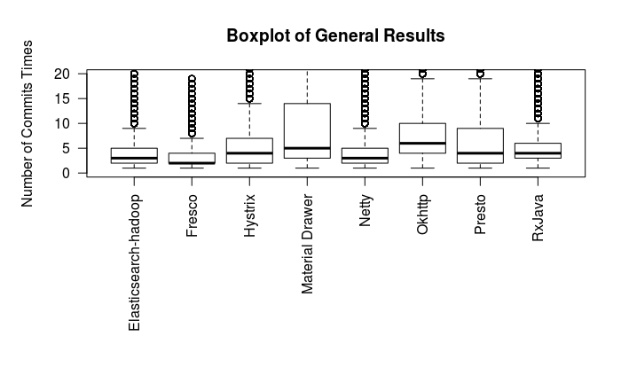

```r
filenames=list.files(path="/home/r4ph/results/classes/analysis/general", full.names=TRUE, recursive = TRUE)
results <- do.call(rbind,lapply(filenames,read.csv))
resultsTimes <- data.frame(lapply(results, as.character), stringsAsFactors=FALSE)
for (i in 1:nrow(resultsTimes)){
  resultsTimes$NtimeofCommits[i] <- length(as.list(strsplit(resultsTimes$timeofCommits[i], ","))[[1]])
}
#par(mfrow = c(2,2), cex = 1.5)
boxplot(resultsTimes$NtimeofCommits ~ resultsTimes$Project, las =2 ,par(mar = c(12, 5, 4, 2)+ 0.1),
        main = "Boxplot of General Results", ylab = "Number of Commits Times", ylim = c(0, 20))
```

[figure not shown]

G4.How many time series pass the preconditions related to defects (preconditions P1, P2, P3)?

G5.How many time series pass the preconditions related to source code metrics (preconditions P4 and P5)?

G6.What is the number of defects potentially covered by our approach?

G7.What are the lags that most led to positive results regarding Granger-causality?

**Observations**

- Analyze the DGC / defects
- Our study defines that time series of bugs is linked to the last insertion point. The previus studies is linked to the commit report.
- Insert recall and precision of model?